# Pre processing - Data reduction

## Tips

- Seek to reduce the data by generating a smaller set of predictors that seek to capture the majority of the information in the original variables.
- Original predictors are needed to create surrogate variables.
- Also known as feature extraction.

## Principal Component Analysis Transform

The PCA transforms the data to return only the principal components, a technique from multivariate statistics and linear algebra.

- Seeks to fund a linear combinations of the predictors.
- First PC is the linear combination that captures most variance. Then subsequent capture remaining variance.
- The transform keeps those components above the variance threshold (default=0.95) or the number of components can be speciﬁed (pcaComp).
- Results in attributes that are uncorrelated.
- Useful for algorithms like linear and generalized linear regression.
- Removes redundant information from multiple predictors.
- Helps with numeric stability.
- Use to extract information from a specific set of predictors?
- Combination coefficients can help to understand which predictors are important to each PC.
- Does not regard further understanding of the predictors. (ie measurement scale or distributions) or modelling objectives.
- Can summarize information not relevant to modelling objectives.
- Naturally drawn to predictors that are in higher orders of magnitude.
- Consider center and scaling, transform skew first.
- If predictive relationship is not connect to predictors variability, then the PCs will not have a suitable relationship to the response. Supervised technique like PLS derive components while considering the response.

### Example

```r
pca_m <- m_input_data(iris) %>% m_standardize_transform() %>% m_pca_transform() %>% m_pre_processed_data() %>% m_variable_statistics()
pca_m %>% m_query(~ variable_statistics)
```

```
## # A tibble: 7 x 11
##   variable type  variance       mean    min  firstQ   median thirdQ   max
##   <chr>    <chr>    <dbl>      <dbl>  <dbl>   <dbl>    <dbl>  <dbl> <dbl>
## 1 Species  fact~   NA      NA         NA     NA      NA      NA     NA
## 2 PC1      nume~    2.92   -3.35e-16  -2.77  -2.10    0.417   1.34   3.30
## 3 PC2      nume~    0.914  -3.60e-17  -2.68  -0.592  -0.0174  0.596  2.65
## 4 Sepal.L~ nume~    0.686   5.84e+ 0   4.3    5.1     5.8     6.4    7.9
## 5 Sepal.W~ nume~    0.190   3.06e+ 0   2      2.8     3       3.3    4.4
## 6 Petal.L~ nume~    3.12    3.76e+ 0   1      1.6     4.35    5.1    6.9
## 7 Petal.W~ nume~    0.581   1.20e+ 0   0.1    0.3     1.3     1.8    2.5
## # ... with 2 more variables: sd <dbl>, skew <dbl>
```

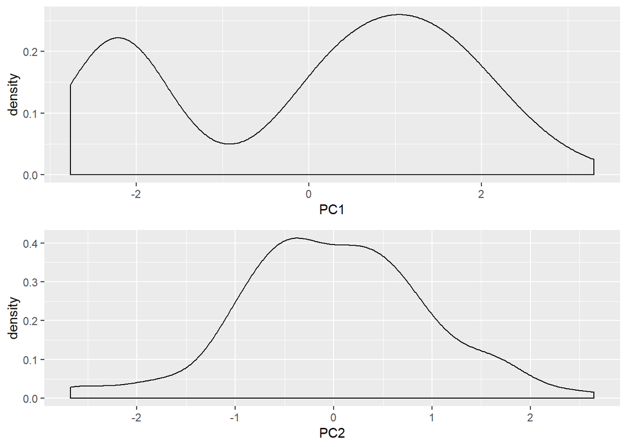

```r
pca_m %>% m_density() %>% m_plot()
```

### Evaluation of PCs

- IF large number of predictors need to decide on number of components to retain.
- Use a scree plot of ordered component number vs summarized variablity. Retain number just prior to tapering off.

### Exploration

Visually examing principal compoents is a critical step for assessing data quality and gaining intuition of the problem.

The first few principals components can be plotted against each other and symbols colored by characteristics,

IF PCA can demonstate clusters of samples or outliers that may prompt a closer examination.

For classification problems PCA can demonstate seperation of classes, or lack thereof. If their is little clustering, the plot of PC values will significant overlap.

Take note of the scale when plotting components. Scale tends to get smaller for later components. Note amount of variation explained by each component.

Another explatory use of PCA is charactrizing which predictors are associated with each component.

If data plotted on seperate scales, their is a tendancy to overinterpret.

## Independent Component Analysis Transform

Transform the data to the independent components. Unlike PCA, ICA retains those components that are independent. You must specify the number of desired independent components with the n.comp argument. This transform may be useful for algorithms such as Naive Bayes.

```r
ica_m <- m_input_data(PimaIndiansDiabetes[, 1:8]) %>% m_standardize_transform() %>% m_ica_transform(n.comp = 5) %>% m_pre_processed_data() %>% m_variable_statistics() %>% m_run()
ica_m %>% m_query(~ variable_statistics)
```

```
## # A tibble: 13 x 11
##    variable type  variance      mean     min  firstQ   median  thirdQ
##    <chr>    <chr>    <dbl>     <dbl>   <dbl>   <dbl>    <dbl>   <dbl>
##  1 ICA1     nume~  1.00e+0  1.14e-16  -4.17   -0.593 -2.38e-2   0.483
##  2 ICA2     nume~  1.00e+0 -2.33e-18  -3.23   -0.649 -1.39e-1   0.472
##  3 ICA3     nume~  1.00e+0  6.55e-17  -1.58   -0.682 -2.60e-1   0.428
##  4 ICA4     nume~  1.00e+0  8.58e-18  -2.38   -0.737  7.37e-2   0.720
##  5 ICA5     nume~  1.00e+0  7.77e-17  -1.41   -0.844 -2.79e-1   0.768
##  6 pregnant nume~  1.14e+1  3.85e+ 0   0       1      3.00e+0   6
##  7 glucose  nume~  1.02e+3  1.21e+ 2   0      99      1.17e+2 140.
##  8 pressure nume~  3.75e+2  6.91e+ 1   0      62      7.20e+1  80
##  9 triceps  nume~  2.54e+2  2.05e+ 1   0       0      2.30e+1  32
## 10 insulin  nume~  1.33e+4  7.98e+ 1   0       0      3.05e+1 127.
## 11 mass     nume~  6.22e+1  3.20e+ 1   0      27.3    3.20e+1  36.6
## 12 pedigree nume~  1.10e-1  4.72e- 1   0.078   0.244  3.72e-1   0.626
## 13 age      nume~  1.38e+2  3.32e+ 1  21      24      2.90e+1  41
## # ... with 3 more variables: max <dbl>, sd <dbl>, skew <dbl>
```

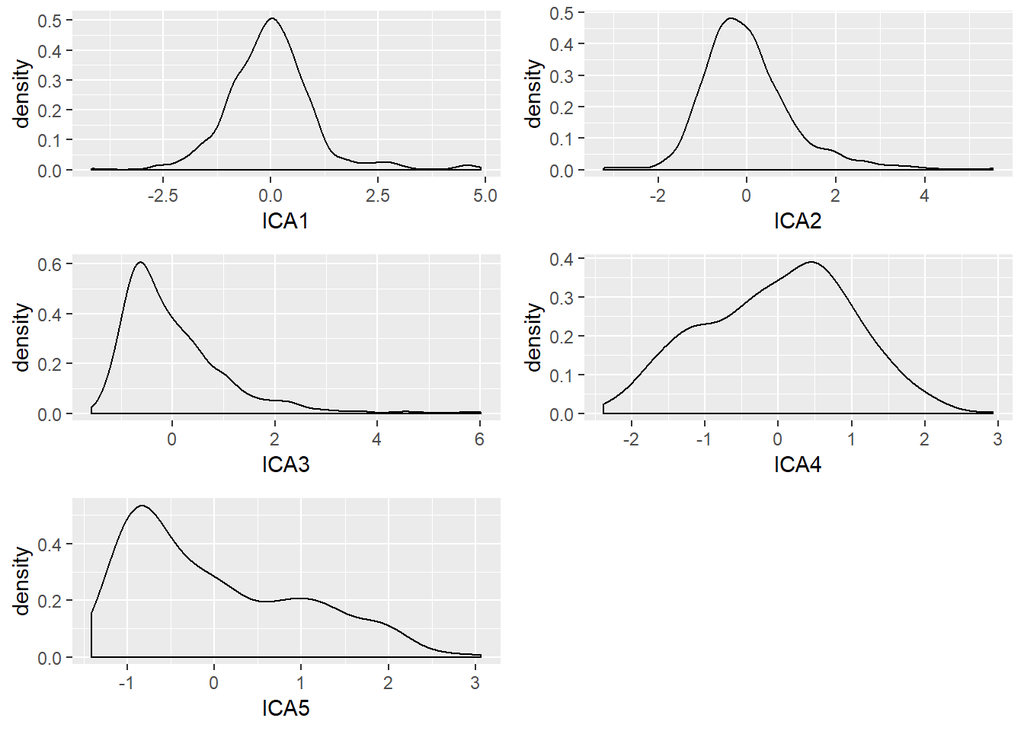

```r
ica_m %>% m_density() %>% m_plot()
```